# Sampling distributions

Dr Juan H Klopper

[figure not shown]

## Preamble

In statistics our aim to to discover information about a population or differences between populations. Populations are enormous and in most cases, we cannot get data from each subject. Instead we pick representative samples from a population or populations and describe or compare those subjects only. This saves time and money and makes discovery about the information we seek possible. Inferential statistics is all about the analysis of our sample data and inferring those result onto the populations.

Just as data point values from samples and populations come in patterns known as distributions, so does statistical values such as the mean, differences in means, standard deviations and so on. These distributions are known as *sampling distributions*.

Sampling distributions form the basis of inferential statistics. They allow us to express common statistical entities such as confidence levels and *p* values. To see this connection, we need to look at the incredible *Central Limit Theorem* (CLT).

## The central limit theorem

The CLT is one of the most beautiful theorems in all of statistics. In this section, we will create a population, draw samples from it, and in the process develop a deep and meaningful understanding of inferential statistics.

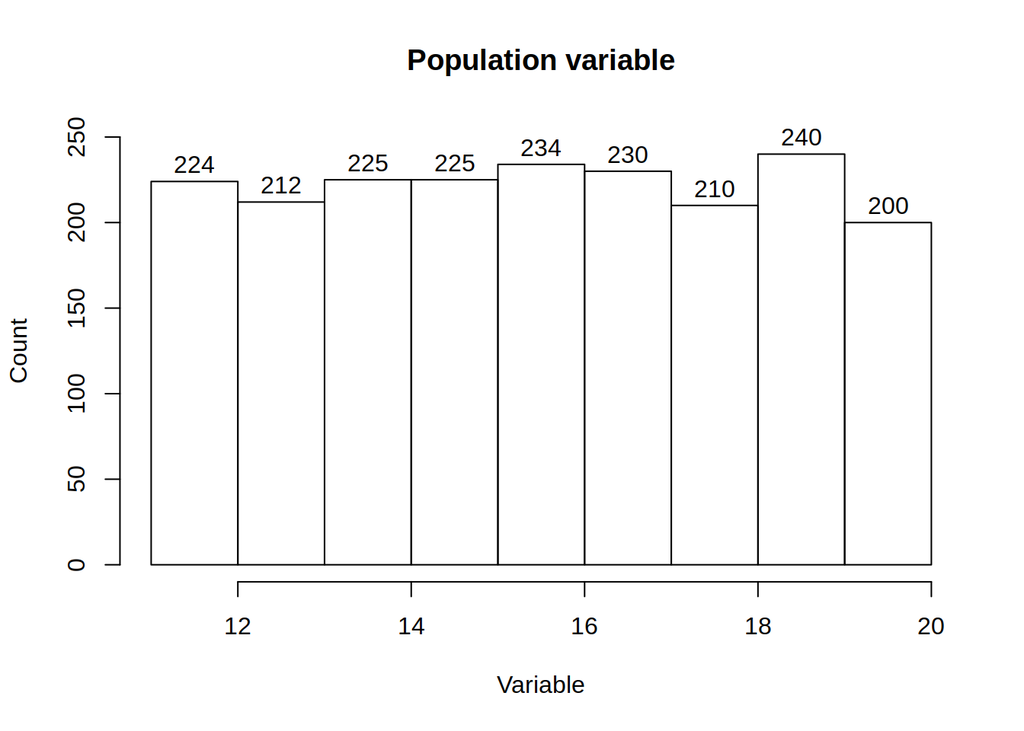

```r
set.seed(123)  # Seed the pseudo-random number generator for reproducible results
population <- runif(2000,
                    min = 11,
                    max = 20)  # Choose 2000 random integers each with equal likelihood
# Create a histogram with counts shown above each bin
hist(population,
     breaks = 10,
     main = "Population variable",
     xlab = "Variable",
     ylab = "Count",
     labels = TRUE,
     xlim = c(11, 20),
     ylim = c(0, 250))
```

The histogram shows that each value appears appears in our dataset with the counts being roughly equal.

Now we consider doing some research on our population. We select $30$ subjects at random and calculate the mean of the variable values.

```r
set.seed(123)
mean(sample(population,
            size = 30,
            replace = TRUE)) # Calculate the mean of 30 random subjects
```

```
## [1] 15.85312
```

We note a mean of $15.9$. Consider the following, though: *What if we started our experiment a week later?* We would get a different random sample of $30$ subjects. We can simulate this with seeding the pseudo-random number generator with a different value. (Remember that we are only using the `set.seed()` function to get reproducible results and by omitting it, we would get different values each time we run the code.)

```r
set.seed(321)
mean(sample(population,
            size = 30,
            replace = TRUE))
```

```
## [1] 15.63116
```

Now we have a mean of $15.6$. What if we ran our experiment $10$ times, recording the mean each time? Well, we would have $10$ *random alues* of a statistical variable. Yes indeed, a statistic such as the mean can be a variable!

In the code chunk below, we use a `for` loop to run our experiment $10$ times, appending the mean of each run of $30$ subjects to an initial empty computer variable called `sample_10`. Then we create a histogram of the $10$ values.

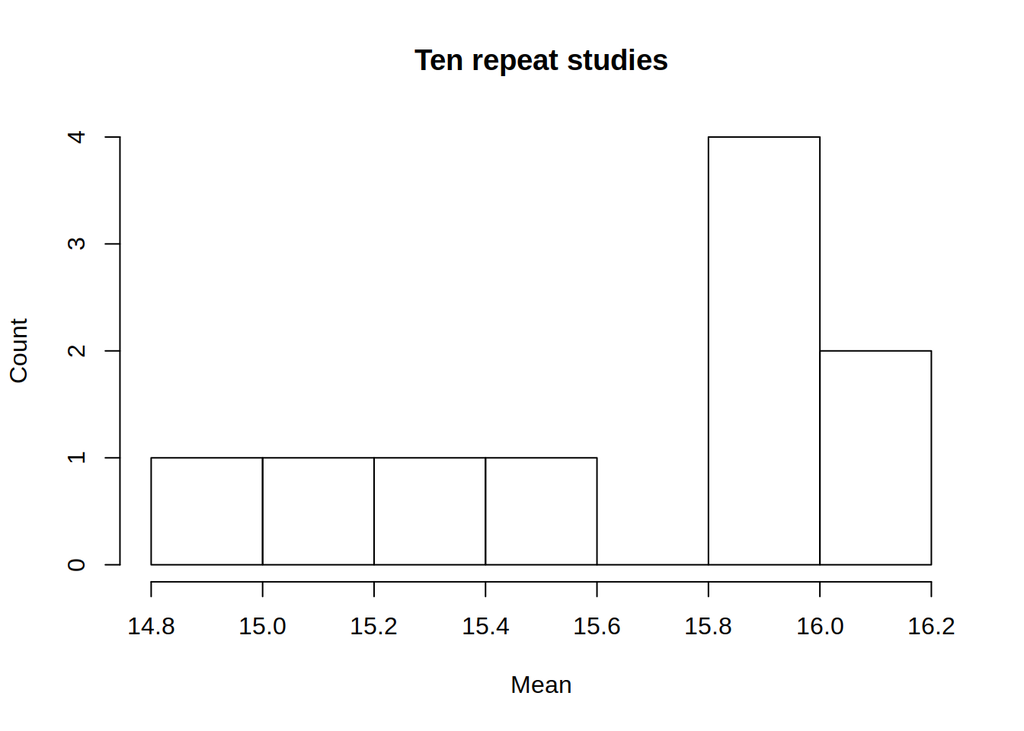

```r
sample_10 <- c()  # Creating an empty vector
set.seed(123)
for (i in 1:10){  # Looping though the experiment 10 times
  sample_10 <- append(sample_10, mean(sample(population, size = 30, replace = TRUE)))}
hist(sample_10,
     main = "Ten repeat studies",
     xlab = "Mean",
     ylab = "Count")
```

Suddenly the distribution does not seem uniform! Let’s repeat our experiment $100$ times. Each time we select $30$ random subjects and calculate a mean, adding it to the vector object `sample_100`.

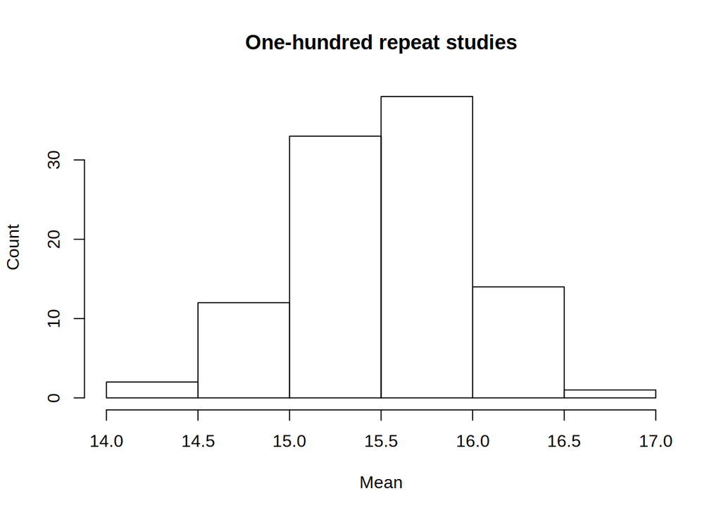

```r
sample_100 <- c()
set.seed(123)
for (i in 1:100){
  sample_100 <- append(sample_100, mean(sample(population, size = 30, replace = TRUE)))}
hist(sample_100,
     main = "One-hundred repeat studies",
     xlab = "Mean",
     ylab = "Count")
```

Now this is interesting. Here goes a thousand repeats.

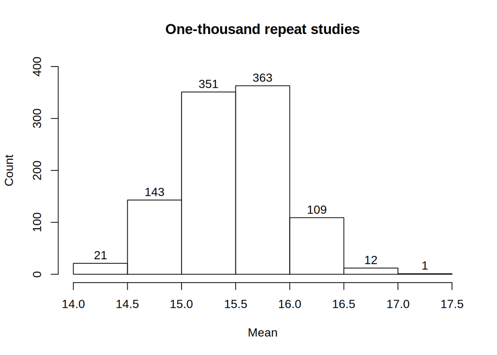

```r
sample_1000 <- c()
set.seed(123)
for (i in 1:1000){
  sample_1000 <- append(sample_1000, mean(sample(population, size = 30, replace = TRUE)))}
hist(sample_1000,
     main = "One-thousand repeat studies",
     xlab = "Mean",
     ylab = "Count",
     ylim = c(0, 400),
     labels = TRUE)
```

What we have here is the CLT in action. A statistic (the mean in this example) tends to a normal distribution as we increase the number of times we randomly calculate it! This is profound. From our $1000$ repeats we see that by chance we would only see a mean of $17$ or more 0.1% of the time or less than $14.5$ 2.1% of the time. If we express this as fraction, that would be 0.001 and 0.021. Letting the cat out of the bag, these are probabilities, leading us to *p* values! In reality, we cannot repeat an experiment $1000$ times. We would do it just once, i.e getting a different mean with a specific probability. That once could be any one of the $1000$ experiments (or more) that we created above.

## The deity experiment

Let’s take the big step and put all of this in perspective. This will allow a thorough understanding of inferential statistics.

Below, we simulate a new research project. We set it up, though, such that we know all the values for a specific variable. In this experiment, there are only $8000$ subjects in the whole population. Imagine some rare disease, or laboratory experiment in which there are only $8000$ specific genetic individuals.

In this experiment, we take two roles. In the first, we are a researcher. We think that the $8000$ subjects are distinct for a specific variable and actual make up two populations. We want to know if there is a statistically significant difference between the two population for the variable under consideration. We also take the role of an imaginary deity. This deity knows that there is no difference between the two populations. We simulate this by creating two sets of vectors, drawing $4000$ random values with the same parameters for each.

```r
set.seed(123)
group_A_population <- sample(30:70,
                             size = 4000,
                             replace = TRUE)
group_B_population <- sample(30:70,
                             size = 4000,
                             replace = TRUE)
```

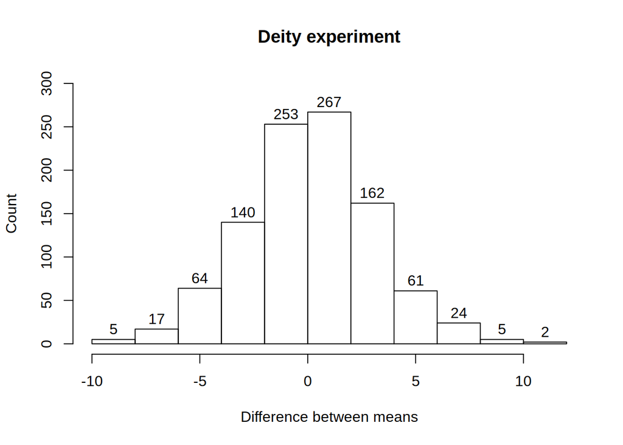

```r
sample_10000 <- c()
for (i in 1:1000){
  sample_10000 <- append(sample_10000,
                         mean(sample(group_A_population, size = 30, replace = TRUE)) -
                           mean(sample(group_B_population, size = 30, replace = TRUE)))
}
hist(sample_10000,
     main = "Deity experiment",
     xlab = "Difference between means",
     ylab = "Count",
     ylim = c(0, 300),
     labels = TRUE)
```

From our deity experiment it was easy to recreate a study many, many times over. In real-life, we only get to do our study once (with others perhaps replicating it later). How then do we know how the histogram above should look like, given that we do not have access to all the repeat studies?

## The *t* distribution

One of the most common sampling distributions is the *t* distribution. If we knew the standard deviation for a variable in a whole population, we can create what is called the *z* distribution. It is bell-shaped with a mean of $0$.

Since we hardly ever know the standard deviation for a variable in a whole population, we make do with the *t* distribution. This sampling distribution requires only one parameter from our data and that is the sample size.

We use the *t* distribution when comparing a numerical variable between two groups. It forms the basis for the famous Student’s *t* test, developed by William Cosset, while working at the Guinness Brewing Company. The parameter we take from our sample is then the sample size minus the number of groups. This is called the *degrees of freedom* (DOF). Since we are comparing two groups, with sample sizes $n_1$ and $n_2$, we will have a DOF value of $n_1 + n_2 - 2$.

The *t* distribution appears very much bell-shaped. For larger sample sizes, this distribution actually approximates the normal distribution.

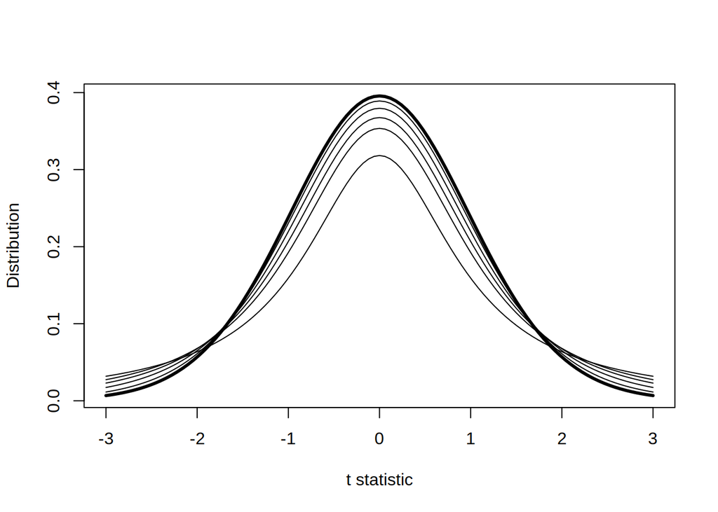

```r
curve(dt(x, df = 30),
      from = -3, to = 3,
      lwd = 3,
      ylab = "Distribution",
      xlab = "t statistic")
ind <- c(1, 2, 3, 5, 10)
for (i in ind) curve(dt(x, df = i), -3, 3, add = TRUE)
```

## The $\chi^2$ distribution

Another common sampling distribution is the $chi^2$ distribution. It also takes one parameter from our sample being the DOF. It is calculated a bit differently, though.

We commonly use the $chi^2$ distribution when dealing with categorical variables. In the graph below, we see a dark line representing a DOF value of $1$. Successive curves have DOF values of $2,3,5$, and,$10$.

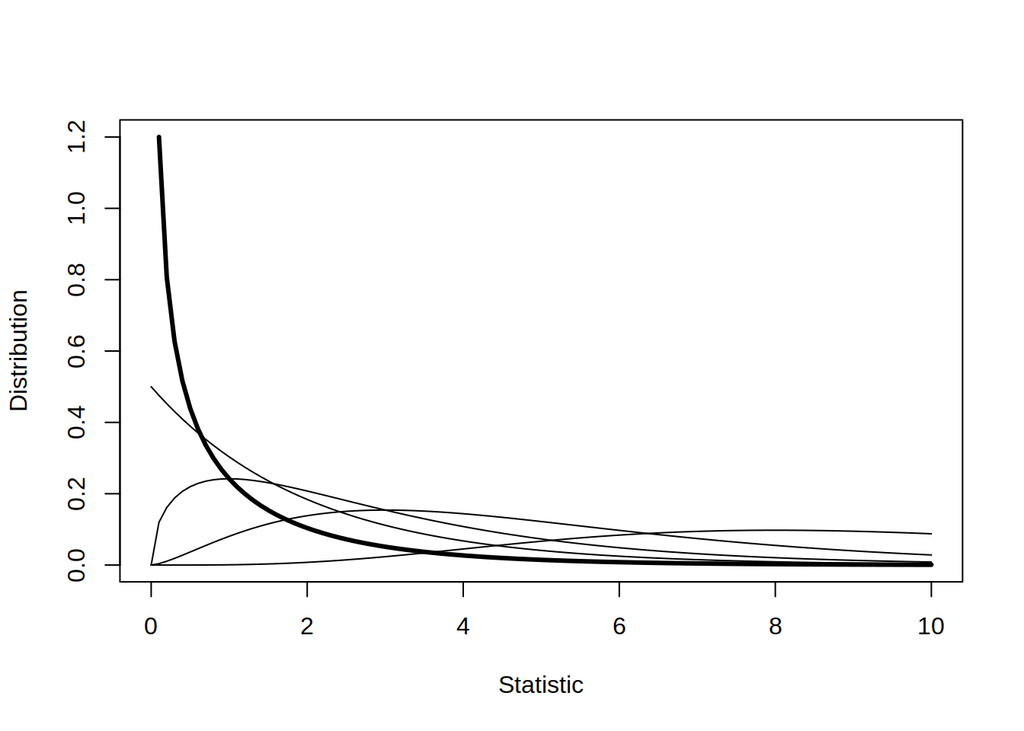

```r
curve(dchisq(x,
             df = 1),
      from = 0,
      to = 10,
      lwd = 3,
      ylab = "Distribution",
      xlab = "Statistic")
ind <- c(2, 3, 5, 10)
for (i in ind) curve(dchisq(x,
                            df = i),
                     0,
                     10,
                     add = TRUE)
```

## Conclusion

We will see these sampling distributions in action when we conduct *t* and $\chi^2$ tests. Their meaning will become crystal clear then.